# matplotlib-1

```python
import numpy as np
import pandas as pd
import matplotlib.pyplot as plt
%matplotlib inline
```

### 图片灰度处理

```python
把彩色图片转化为黑白图片
```

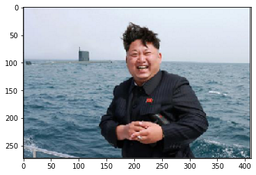

```python
jin = plt.imread('jinzhengen.png')
plt.imshow(jin)
```

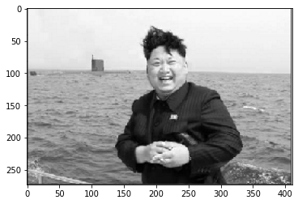

```python
# 最大值法
jin_max = jin.max(axis=2)
jin_max.shape
plt.imshow(jin_max, cmap='gray')
```

[output not shown]

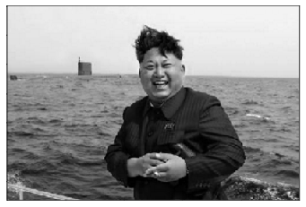

```python
# 最小值法
jin_min = jin.min(axis=2)
jin_min.shape
plt.imshow(jin_min, cmap='gray')
plt.axis('off')
```

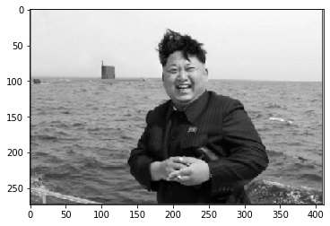

```python
# 平均值
jin_mean = jin.mean(axis=2)
jin_mean.shape
plt.imshow(jin_mean, cmap='gray')
```

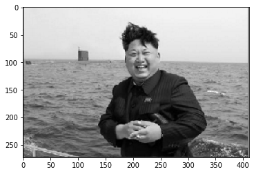

```python
# 加权平均
jin_weight = np.dot(jin, [0.299,0.587,0.114]) / 3
plt.imshow(jin_weight, cmap='gray')
```

# matplotlib

## 目录

- 一、【重点】Matplotlib基础知识
- 二、设置plot的风格和样式
  - 1、【重点】点和线的样式
  - 2、X、Y轴坐标刻度
- 三、2D图形
  - 1、示例
  - 2、【重点】直方图
  - 3、【重点】条形图
  - 4、【重点】饼图
  - 5、【重点】散点图

=============以上为重点=================

#### 下面的自学

- 四、图形内的文字、注释、箭头
  - 1、图形内的文字
  - 2、注释
  - 3、箭头
- 五、3D图
  - 1、曲面图

## 一、Matplotlib基础知识

Matplotlib中的基本图表包括的元素

- x轴和y轴  
  水平和垂直的轴线
- x轴和y轴刻度  
  刻度标示坐标轴的分隔，包括最小刻度和最大刻度
- x轴和y轴刻度标签  
  表示特定坐标轴的值
- 绘图区域  
  实际绘图的区域

```python
#pandas 绘图，提供方便
#matplotlib专门绘图工具，样式更加丰富
```

### 只含单一曲线的图

```python
n = np.array(np.random.randint(0,10, size=10))
n
```

```
array([7, 3, 5, 5, 2, 8, 2, 5, 9, 5])
```

```python
# plt.plot只能画线型图,它没有kind, plt.bar, plt.hist, plt.scatter
plt.plot(np.arange(10), n)
```

```python
# plt.plot中,x轴的数据不是必须的, 不传x轴数据,会自动使用y轴数据的索引作为x轴数据.
plt.plot(n)
```

### 包含多个曲线的图

1、可以使用多个plot函数（推荐），在一个图中绘制多个曲线

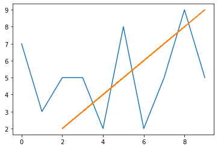

```python
plt.plot(n) # 调用一次就会在当前画布中画出一条曲线
plt.plot(n,n)
```

2、也可以在一个plot函数中传入多对X,Y值，在一个图中绘制多个曲线

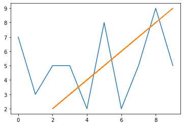

```python
plt.plot(np.arange(0,10), n , n, n)
```

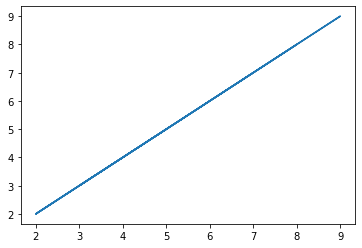

```python
plt.plot(n) # 调用一次就会在当前画布中画出一条曲线
plt.show()
plt.plot(n,n)
```

### 网格线

绘制正选余弦

使用plt.grid(True)方法为图添加网格线

设置grid参数（参数与plot函数相同），使用plt面向对象的方法，创建多个子图显示不同网格线

[figure not shown]

- lw代表linewidth，线的粗细
- alpha表示线的明暗程度
- color代表颜色

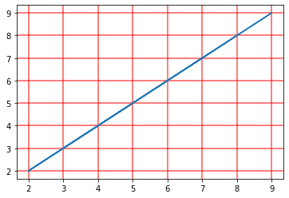

```python
plt.plot(n,n)
plt.grid(lw=2, c='r', ls='-', alpha=0.5)
```

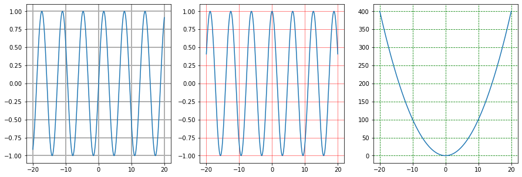

```python
# 画子图有两种方法
x = np.linspace(-20, 20,  1000)
plt.figure(figsize=(3*5, 5))
axes1 = plt.subplot(1, 3, 1)
axes1.plot(x, np.sin(x))
axes1.grid(lw=2)

axes2 = plt.subplot(1,3, 2)
axes2.plot(x, np.cos(x))
axes2.grid(c='r', alpha=0.6)

axes3 = plt.subplot(1,3,3)
axes3.plot(x, x**2)
axes3.grid(c='g', ls='--')
```

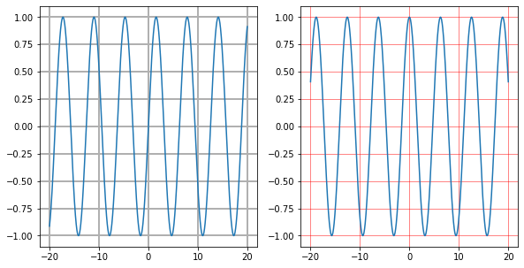

```python
# 另一种画子图的方法
figure = plt.figure(figsize=(3*5, 5))
axes1 = figure.add_subplot(1,3,1)
axes1.plot(x, np.sin(x))
axes1.grid(lw=2)

axes2 = figure.add_subplot(1,3,2)
axes2.plot(x, np.cos(x))
axes2.grid(c='r', alpha=0.6)
```

### 坐标轴界限

#### axis方法

如果axis方法没有任何参数，则返回当前坐标轴的上下限axis(xmin =,ymax = )

```
(-1, 3, -1.0, 1.0)
```

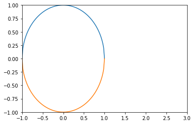

```python
x = np.linspace(-1,1, 100)
y = (1 - x**2) ** 0.5
plt.plot(x, y, x, -y)
# 显示当前坐标轴的界限
plt.axis()
# 设置坐标轴界限
plt.axis([-1,1, -1,1])

# 单独 设置 x轴界限
plt.axis(xmin=-1, xmax=3)
```

##### plt.axis('xxx') 'tight'、'off'、'equal'……

设置坐标轴类型  
关闭坐标轴

[figure not shown]

```
(-1.1, 1.1, -1.0999438818457405, 1.0999438818457405)
```

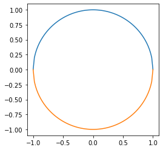

```python
plt.plot(x, y, x, -y)
# 默认是tight, 紧凑的分割
# plt.axis('equal')

# 取消坐标轴
plt.axis('scaled')
```

#### xlim方法和ylim方法

除了plt.axis方法，还可以通过xlim，ylim方法设置坐标轴范围

```
(-2, 2)
```

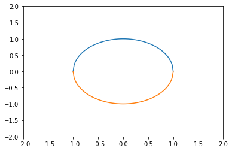

```python
plt.plot(x, y, x, -y)
# 只能单独设置x轴刻度
plt.xlim(xmin=-2, xmax=2)
plt.ylim(-2,2)
```

### 坐标轴标签

xlabel方法和ylabel方法  
plt.ylabel('y = x^2 + 5',rotation = 60)旋转

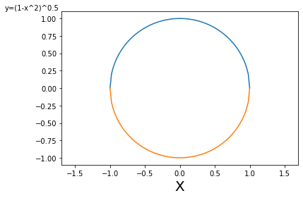

```python
plt.plot(x, y, x, -y)

plt.axis('equal')
# 设置x轴的标签
plt.xlabel('X', fontdict=dict(fontsize=20))
plt.ylabel('y=(1-x^2)^0.5', rotation=0, position=(0.5,1))
```

### 标题

title方法

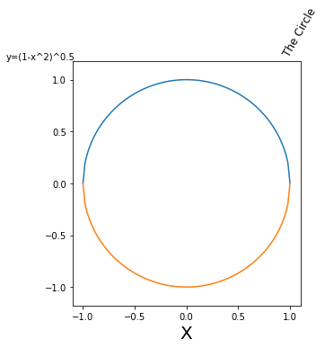

```python
plt.figure(figsize=(2*5, 5))
axes1 = plt.subplot(1,2,1)
axes1.plot(x, y, x, -y)
axes1.axis('equal')
# 设置x轴的标签
# 子图要使用set_xxx
axes1.set_xlabel('X', fontdict=dict(fontsize=20))
axes1.set_ylabel('y=(1-x^2)^0.5', rotation=0, position=(0.5,1))
axes1.set_title('The Circle', rotation=60, position=(1,1))
```

### 图例

#### legend方法

两种传参方法：

- 【推荐使用】在plot函数中增加label参数
- 在legend方法中传入字符串列表

[figure not shown]

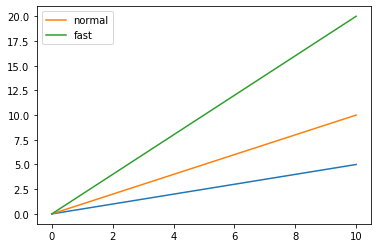

```python
# 推荐写法
x = np.linspace(0,10,  10)
# 图例名称不要以下划线开头
plt.plot(x, 0.5 * x, label='_slow')
plt.plot(x, x, label='normal')
plt.plot(x,  2*  x, label='fast')
# 自动的寻找一个 最好的位置best()来放置图裂
plt.legend()
```

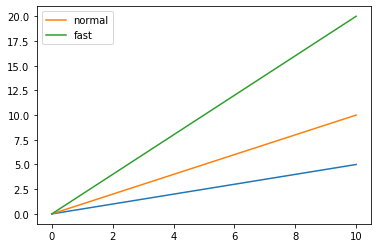

```python
# 第二种创建图例的方法
x = np.linspace(0,10,  10)
plt.plot(x, 0.5 * x)
plt.plot(x, x)
plt.plot(x,  2*  x)
# 自动的寻找一个 最好的位置best()来放置图裂
plt.legend(['_slow', 'normal', 'fast'])
```

label参数为'_xxx'，则图例中不显示  
plt.plot(x, x*1.5, label = '_xxx')

### loc参数

| 字符串 | 数值 | 字符串 | 数值 |
| --- | --- | --- | --- |
| best | 0 | center left | 6 |
| upper right | 1 | center right | 7 |
| upper left | 2 | lower center | 8 |
| lower left | 3 | upper center | 9 |
| lower right | 4 | center | 10 |
| right | 5 |  |  |

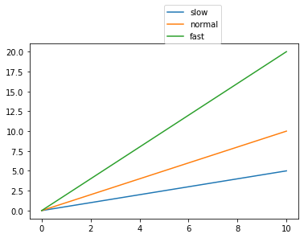

```python
x = np.linspace(0,10,  10)
# 图例名称不要以下划线开头
plt.plot(x, 0.5 * x, label='slow')
plt.plot(x, x, label='normal')
plt.plot(x,  2*  x, label='fast')
# 自动的寻找一个 最好的位置best()来放置图裂
# plt.legend(loc='center left')
# loc = location
plt.legend(loc=(0.5,1))
```

loc参数可以是2元素的元组，表示图例左下角的坐标

图例也可以超过图的界限loc = (-0.1,0.9)

### ncol参数

ncol控制图例中有几列

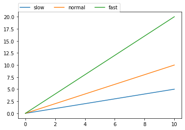

```python
x = np.linspace(0,10,  10)
# 图例名称不要以下划线开头
plt.plot(x, 0.5 * x, label='slow')
plt.plot(x, x, label='normal')
plt.plot(x,  2*  x, label='fast')
# 自动的寻找一个 最好的位置best()来放置图裂
# plt.legend(loc='center left')
# loc = location
plt.legend(loc=(0,1), ncol=3)
```

### linestyle、color、marker

修改线条样式

[figure not shown]

### 保存图片

figure.savefig的选项

- filename  
  含有文件路径的字符串或Python的文件型对象。图像格式由文件扩展名推断得出，例如，.pdf推断出PDF，.png推断出PNG （“png”、“pdf”、“svg”、“ps”、“eps”……）
- dpi  
  图像分辨率（每英寸点数），默认为100
- facecolor  
  图像的背景色，默认为“w”（白色）

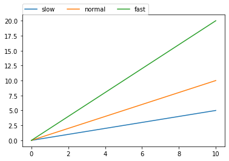

```python
figure = plt.figure()
x = np.linspace(0,10,  10)
# 图例名称不要以下划线开头
plt.plot(x, 0.5 * x, label='slow')
plt.plot(x, x, label='normal')
plt.plot(x,  2*  x, label='fast')
# 自动的寻找一个 最好的位置best()来放置图裂
# plt.legend(loc='center left')
# loc = location
plt.legend(loc=(0,1), ncol=3)
figure.savefig('legend.jpg',  dpi=500, facecolor='g')
```